# Código Equipo 2

(Previamente descargamos los datos de la página web: https://aging.brain-map.org/download/index y extrajimos *fpkm_table_normalized.csv* de la carpeta comprimida)

## Cargar bibliotecas:

```r
library(NeurocienciasIntroData)
library(data.table)
library(dplyr)
library(ggplot2)
```

## Elegir el archivo con los datos a ocupar:

En ventana emergente se debe buscar el archivo *fpkm_table_normalized.csv*.

```r
tbi_file <- choose.files()
```

### Creamos la variable *normalized.rna.measures*

Cambiamos el nombre de las columnas para facilitar su manipulación.

```r
normalized.rna.measures <- fread(tbi_file)
setnames(normalized.rna.measures, "gene_id \\ rnaseq_profile_id", "gene_id")

normalized.rna.measures <- melt(normalized.rna.measures, id.vars = "gene_id",
  variable.name = "rnaseq_profile_id")
```

#### Creamos un archivo csv llamado *rna_data.csv*

Si limpiamos nuestro ambiente podemos simplemente leer este archivo de nuevo.

```r
fwrite(normalized.rna.measures, "rna_data.csv", row.names = F)
```

##### Para leer el archivo rna_data.csv:

En ventana emergente se debe buscar el archivo *rna_data.csv*.

```r
normalized.rna.measures <- fread(choose.files())
```

## Unir información de ARN con información de sujetos:

### Convertimos en factores las columnas correspondientes:

```r
normalized.rna.measures[, gene_id := as.factor(gene_id)]
normalized.rna.measures[, rnaseq_profile_id := as.factor(rnaseq_profile_id)]
```

#### Guardamos la información pertinente de los donadores

```r
donor.info.dt <- donor.information
setDT(donor.info.dt)
donor.info.dt[, .(donor_id, ever_tbi_w_loc, dsm_iv_clinical_diagnosis, braak)]
```

#### Guardamos la informacón pertinente de los genes y de las muestras

```r
rows.genes.dt <- rows.genes[, .(gene_id, gene_symbol)]

column.samples.dt <- column.samples[, .(rnaseq_profile_id, donor_id,hemisphere,
                                        structure_acronym)]
```

##### Unimos la informacion de los valores del ARN con la información de los genes

Nos aseguramos de que correspondan usando la etiqueta *gene_id*.

```r
rna.measure.genes <- merge(rows.genes.dt, normalized.rna.measures,
                          by = "gene_id")
```

##### Ahora unimos con la información de las muestras

En este paso agregamos la información de los hemisferios y de las estructuras. Nos aseguramos de que correspondan usando la etiqueta *rnaseq_profile_id*.

```r
rna.measure.genes <- merge(column.samples.dt, rna.measure.genes,
                          by = "rnaseq_profile_id")
```

##### Por último, unimos con la información relevante de los donadores

Nos aseguramos de que correspondan usando la etiqueta *donor_id*. (Nota: Ejecutar este chunk puede ser tardado)

```r
rna.measure.genes <- merge(
  donor.information[, .(
    donor_id = as.factor(donor_id), ever_tbi_w_loc, braak,
    dsm_iv_clinical_diagnosis )], rna.measure.genes,
  by = "donor_id")
```

## Filtrados y creación de grupo_AD:

Ahora ya se puede hacer un data frame que contenga las muestras que deseamos; sin embargo, optamos por hacerlo por partes para ver cuáles se iban eliminando y porqué razón. Buscamos un estricto control de variables, por lo que elegimos ocupar solamente un hemisferio y se eligió el derecho porque es del que se tienen más muestras.

### Elegimos los genes de nuestro interés

Seleccionamos MBP y PLP1, de materia blanca del lóbulo parietal derecho

```r
MBP_PLP1_FWM <- rna.measure.genes[(gene_symbol == "MBP" &
             structure_acronym == "FWM" & hemisphere == "right" ) |
             (gene_symbol == "PLP1" &  structure_acronym == "FWM"&
              hemisphere == "right")]
```

#### Seleccionamos las muestras de MBP y PLP1 de los sujetos con AD

Son 16 sujetos con AD sin TBI, pero se eliminó uno que no tiene los valores para ninguno de los genes de nuestro interés y se eliminaron 2 cuya información es del hemisferio izquierdo, quedando 13.

```r
MBP_AD_sin_TBI <- subset(MBP_PLP1_FWM,
                     dsm_iv_clinical_diagnosis == "Alzheimer's Disease Type" &
                      ever_tbi_w_loc == "N" & gene_symbol == "MBP")

PLP1_AD_sin_TBI <- subset(MBP_PLP1_FWM,
                     dsm_iv_clinical_diagnosis == "Alzheimer's Disease Type" &
                      ever_tbi_w_loc == "N" & gene_symbol == "PLP1")
```

##### Quitamos algunas columnas que se repetirían al unir los subsets

```r
PLP1_AD_sin_TBI <- select(PLP1_AD_sin_TBI, -dsm_iv_clinical_diagnosis,
                        -hemisphere, -braak)
```

##### Unimos la información de los subsets con la etiqueda donor_id

Las columnas con nombre repetido que necesitaremos tomarán el sufijo del subset del que provienen para poder distinguirlas.

```r
grupo_AD <- merge(PLP1_AD_sin_TBI, MBP_AD_sin_TBI, by = "donor_id",
                  suffixes = c(".PLP1",".MBP"))
```

##### Por último, elegimos solamente los datos que ocuparemos

```r
grupo_AD <- grupo_AD[, .(donor_id,dsm_iv_clinical_diagnosis,
                       hemisphere, value.PLP1, value.MBP, braak)]
count(grupo_AD)
```

| n |
| --- |
| 13 |

## Resultado: grupo_AD: 13 sujetos con AD sin TBI, unidos por el *donor_id*

## Filtrados y creación de grupo_control:

### Seleccionamos las muestras de MBP y PLP1 de los sujetos sin AD ni TBI

Son 27 sin AD ni TBI, pero se eliminaron 13 cuya información pertenece al hemisferio izquierdo, quedan 14.

```r
PLP1_sanos <- subset(MBP_PLP1_FWM, dsm_iv_clinical_diagnosis == "No Dementia" &
                     ever_tbi_w_loc == "N" & gene_symbol == "PLP1")
count(PLP1_sanos)
```

| n |
| --- |
| 14 |

#### Eliminamos al sujeto que no tiene los valores para PLP1

Al revisar *PLP_sanos*, vemos que hay un sujeto que no tiene los valores de PLP1, pero entró a *MBP_PLP1_FWM* porque sí tiene la información de MBP. Una vez excluído quedan 13 sujetos.

```r
PLP1_control <- subset(PLP1_sanos, donor_id != 326765689)
count(PLP1_control)
```

| n |
| --- |
| 13 |

Hacemos lo mismo para MBP, primero obtenemos los 14 sin AD ni TBI previamente mencionados.

```r
MBP_sanos <- subset(MBP_PLP1_FWM, dsm_iv_clinical_diagnosis == "No Dementia" &
                    ever_tbi_w_loc == "N" & gene_symbol == "MBP")
count(MBP_sanos)
```

| n |
| --- |
| 14 |

Después, elegimos solamente a las muestras de MBP sin AD ni TBI cuyos donadores se encuentren en el subset *PLP1_control*, usando el *donor_id*. De este modo eliminamos también de este subset al sujeto del que se tienen valores para MBP pero no para PLP1, quedando los mismos 13.

```r
MBP_control <- MBP_sanos[MBP_sanos$donor_id %in% PLP1_control$donor_id, ]
count(MBP_control)
```

| n |
| --- |
| 13 |

##### Quitamos algunas columnas que se repetirían al unir los subsets

```r
MBP_control <- select(MBP_control, -dsm_iv_clinical_diagnosis,
                    -hemisphere, -braak)
```

##### Unimos la informacion de los subsets con la etiqueta donor_id

Las columnas con nombre repetido que necesitaremos toman el sufijo del subset del que provienen para poder distinguirlas

```r
grupo_control <- merge(PLP1_control, MBP_control, by = "donor_id",
                       suffixes = c(".PLP1",".MBP"))
```

##### Por último, elegimos solamente los datos que ocuparemos

Resultado: grupo_control: 13 sujetos sin AD ni TBI, unidos por el *donor_id*.

```r
grupo_control <- grupo_control[, .(donor_id, dsm_iv_clinical_diagnosis,
                                 hemisphere, value.PLP1, value.MBP, braak)]
count(grupo_control)
```

| n |
| --- |
| 13 |

Nuestro grupo control tiene mismo número que el grupo AD, por lo que no será necesario hacer un submuestreo aleatorio. —

## Data frames que contengan ambos grupos

### Creamos un data frame uniendo las filas de nuestros dos grupos

```r
Ambos_grupos <- rbind(grupo_AD, grupo_control)
count(Ambos_grupos)
```

| n |
| --- |
| 26 |

Resultado: 26 filas, 13 del grupo AD y 13 del grupo control

### Crearemos un data frame filtrando toda la información inicial directamente

Esto le da una estructura diferente al data frame y nos facilitará ocuparlo para graficar los resultados más adelante.

```r
Todos <- MBP_PLP1_FWM[(donor_id != 326765689 & ever_tbi_w_loc == "N" &
                     (dsm_iv_clinical_diagnosis == "Alzheimer's Disease Type" |
                        dsm_iv_clinical_diagnosis == "No Dementia"))]
count(Todos)
```

| n |
| --- |
| 52 |

Resultado: 52 filas: 13 de MBP con AD, 13 de PLP1 con AD, 13 de MBP sin AD y 13 de PLP1 sin AD. —

## Análisis exploratorio de los datos

### Cálculo del poder estadístico

Conociendo la *n* final, ya podemos calcular el *poder estadístico* que tendrá el análisis. Ya que buscamos una diferencia en la cola inferior, pues esperamos que estén más bajos los niveles del grupo AD con respecto al control, el tamaño del efecto (la *d* de Cohen) lo debemos poner negativo.

Cabe recordar que el nivel de significación, alfa, es la probabilidad de cometer un error de tipo I: rechazar la hipótesis nula cuando es verdadera (falso positivo). Y el poder estadístico, 1-beta, es la probabilidad de **no** cometer un error de tipo II: aceptar la hipótesis nula cuando es falsa (falso negativo).

```r
pwr::pwr.t.test(n = 13, d = -0.8, sig.level = 0.05,
           type = "two.sample", alternative = "less",
           power = NULL)
```

```
     Two-sample t test power calculation

              n = 13
              d = -0.8
      sig.level = 0.05
          power = 0.6318458
    alternative = less

NOTE: n is number in *each* group
```

Poder = 0.6318458  
Nivel de confianza = (1-alfa)*100 = 95%

### Calculo de la n ideal

```r
pwr::pwr.t.test(n = NULL,
                d = -0.8, sig.level = 0.05, type = "two.sample",
                alternative = "less", power = 0.8)
```

```
     Two-sample t test power calculation

              n = 20.03277
              d = -0.8
      sig.level = 0.05
          power = 0.8
    alternative = less

NOTE: n is number in *each* group
```

n = 20.03277

### Gráficos de densidad para observar distribuciones

En rojo está la densidad de los valores de ARN del grupo con AD y en verde la densidad de los valores de ARN del grupo control.

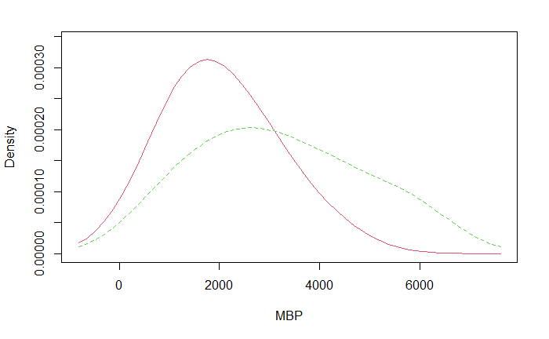

```r
sm::sm.density.compare(Ambos_grupos$value.MBP, as.factor(
  Ambos_grupos$dsm_iv_clinical_diagnosis), xlab="MBP")
```

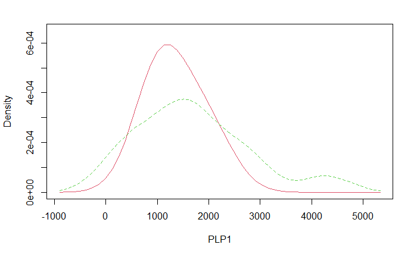

```r
sm::sm.density.compare(Ambos_grupos$value.PLP1, as.factor(
  Ambos_grupos$dsm_iv_clinical_diagnosis), xlab="PLP1")
```

### Comprobación de normalidad

Hacemos un test de Shapiro-Wilk para corroborar que las muestras se ajusten a una distribución normal.

```r
shapiro.test(grupo_AD$value.MBP)
```

```
    Shapiro-Wilk normality test

data:  grupo_AD$value.MBP
W = 0.95683, p-value = 0.7043
```

```r
shapiro.test(grupo_AD$value.PLP1)
```

```
    Shapiro-Wilk normality test

data:  grupo_AD$value.PLP1
W = 0.91047, p-value = 0.1861
```

```r
shapiro.test(grupo_control$value.MBP)
```

```
    Shapiro-Wilk normality test

data:  grupo_control$value.MBP
W = 0.97549, p-value = 0.9501
```

```r
shapiro.test(grupo_control$value.PLP1)
```

```
    Shapiro-Wilk normality test

data:  grupo_control$value.PLP1
W = 0.94837, p-value = 0.5739
```

Podemos ver que todas tiene una p mayor a alfa, por lo que no se rechaza la hipótesis nula de que las muestras provienen de una distribución normal

### Q-Q plots

Gráfico cuantil-cuantil para observar dispersiones en las distribuciones

```
[1] 2 9
```

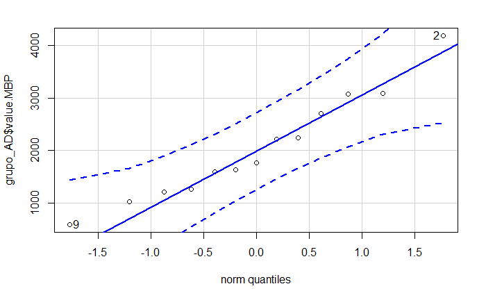

```r
car::qqPlot(grupo_AD$value.MBP)
```

```
[1] 2 9
```

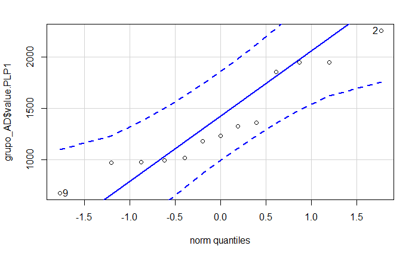

```r
car::qqPlot(grupo_AD$value.PLP1)
```

```
[1] 8 4
```

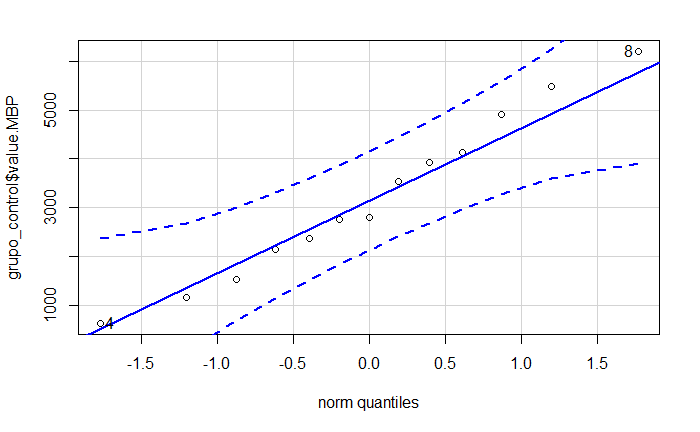

```r
car::qqPlot(grupo_control$value.MBP)
```

```
[1]  8 11
```

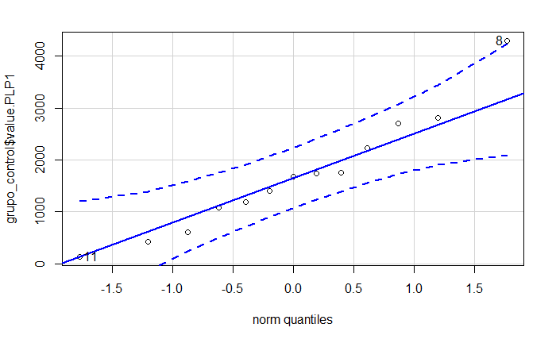

```r
car::qqPlot(grupo_control$value.PLP1)
```

En el eje de las abscisas están los cuantiles teóricos de la distribución normal, en el eje de las ordenadas están los cuantiles reales de la muestra.

#### Comprobación de homocedasticidad

Hacemos un test de Bartlett para corroborar homogeneidad de varianza.

```r
bartlett.test(list(grupo_AD$value.MBP,grupo_control$value.MBP))
```

```
    Bartlett test of homogeneity of variances

data:  list(grupo_AD$value.MBP, grupo_control$value.MBP)
Bartlett's K-squared = 2.9524, df = 1, p-value = 0.08575
```

El test no encontró diferencia en las varianzas de MBP en los dos grupos (p>alfa).

```r
bartlett.test(list(grupo_AD$value.PLP1,grupo_control$value.PLP1))
```

```
    Bartlett test of homogeneity of variances

data:  list(grupo_AD$value.PLP1, grupo_control$value.PLP1)
Bartlett's K-squared = 7.4082, df = 1, p-value = 0.006493
```

El test **sí encontró diferencia en las varianzas de PLP1** en los 2 grupos (p<alfa) —

## Análisis estadístico de los datos

### Calculo de las medidas de tendencia central y la desviación estándar

Para MBP:

```r
Ambos_grupos %>% group_by(dsm_iv_clinical_diagnosis) %>% summarise(
  MBP_media = mean(value.MBP), MBP_mediana = median(value.MBP),
  MBP_desviacion_estandar = sd(value.MBP),
  MBP_coef_variacion = sd(value.MBP)/mean(value.MBP))
```

| dsm_iv_clinical_diagnosis | MBP_media | MBP_mediana | MBP_desviacion_estandar | MBP_coef_variacion |
| --- | --- | --- | --- | --- |
| Alzheimer's Disease Type | 2047.141 | 1761.724 | 1008.140 | 0.4924623 |
| No Dementia | 3202.342 | 2806.136 | 1690.846 | 0.5280028 |

Para PLP1:

```r
Ambos_grupos %>% group_by(dsm_iv_clinical_diagnosis) %>% summarise(
  PLP1_media = mean(value.PLP1), PLP_mediana = median(value.PLP1),
  PLP1_desviacion_estandar = sd(value.PLP1),
  PLP1_coef_variacion = sd(value.PLP1)/mean(value.PLP1))
```

| dsm_iv_clinical_diagnosis | PLP1_media | PLP_mediana | PLP1_desviacion_estandar | PLP1_coef_variacion |
| --- | --- | --- | --- | --- |
| Alzheimer's Disease Type | 1366.743 | 1235.784 | 483.9827 | 0.3541138 |
| No Dementia | 1699.810 | 1684.628 | 1127.2678 | 0.6631726 |

### Intervalos de confianza y pruebas t

#### Intervalos de confianza unilaterales para la media:

```r
t.test(grupo_AD$value.MBP, alternative = "less")$conf.int
```

```
[1]     -Inf 2545.482
attr(,"conf.level")
[1] 0.95
```

```r
t.test(grupo_control$value.MBP, alternative = "less")$conf.int
```

```
[1]     -Inf 4038.157
attr(,"conf.level")
[1] 0.95
```

```r
t.test(grupo_AD$value.PLP1, alternative = "less")$conf.int
```

```
[1]     -Inf 1605.984
attr(,"conf.level")
[1] 0.95
```

```r
t.test(grupo_control$value.PLP1, alternative = "less")$conf.int
```

```
[1]     -Inf 2257.039
attr(,"conf.level")
[1] 0.95
```

Con los intervalos de confianza unilaterales podemos concluir con un nivel de confianza del 95% que:

Los valores promedio de MBP para el grupo con AD son menores a 2545.482 FPKM. Los valores promedio de MBP para el grupo control son menores a 4038.157 FPKM.

Los valores promedio de PLP1 para el grupo con AD son menores a 1605.984 FPKM. Los valores promedio de PLP1 para el grupo control son menores a 2257.039 FPKM.

#### Pruebas t para comparar las medias de 2 grupos independientes

Para MBP basta usar una prueba t de student porque los supuestos de normalidad y homocedasticidad ya fueron comprobados.

```r
t.test(value.MBP ~ dsm_iv_clinical_diagnosis, Ambos_grupos,
       var.equal = TRUE, alternative = "less")
```

```
    Two Sample t-test

data:  value.MBP by dsm_iv_clinical_diagnosis
t = -2.1158, df = 24, p-value = 0.02246
alternative hypothesis: true difference in means is less than 0
95 percent confidence interval:
      -Inf -221.0841
sample estimates:
mean in group Alzheimer's Disease Type              mean in group No Dementia
                              2047.141                               3202.342
```

**Hay diferencia en MBP**, p < alfa (*p-value = 0.02246). Diferencia de las medias = 2047.141 - 3202.342 = -1155.201 Es negativa porque es menor la media del grupo con AD. Podemos concluir con un nivel de confianza del 95% que: los FPKM promedio de MBP del grupo con AD **son inferiores** a los FPKM promedio de MBP del grupo control, ya que el intervalo de confianza no incluye el cero y el límite resultó negativo. (La expresión media de MBP del grupo con AD es menor que la expresión media de MBP del grupo control)

##### Comprobación de la diferencia en MBP con prueba t para varianzas desiguales

```r
t.test(value.MBP ~ dsm_iv_clinical_diagnosis, Ambos_grupos,
       var.equal = FALSE, alternative = "less")
```

```
    Welch Two Sample t-test

data:  value.MBP by dsm_iv_clinical_diagnosis
t = -2.1158, df = 19.575, p-value = 0.02369
alternative hypothesis: true difference in means is less than 0
95 percent confidence interval:
      -Inf -212.5361
sample estimates:
mean in group Alzheimer's Disease Type              mean in group No Dementia
                              2047.141                               3202.342
```

*p-value = 0.02369. Sí hay diferencia en MBP.

#### Prueba t de Welch para PLP1

Para PLP1 se necesita una prueba t adaptada a varianzas desiguales ya que las muestras son heterocedásticas, por lo que usaremos una prueba t de Welch. La misma con la que comprobamos la diferencia de MBP.

```r
t.test(value.PLP1 ~ dsm_iv_clinical_diagnosis, Ambos_grupos,
       var.equal = FALSE, alternative = "less")
```

```
    Welch Two Sample t-test

data:  value.PLP1 by dsm_iv_clinical_diagnosis
t = -0.9789, df = 16.279, p-value = 0.171
alternative hypothesis: true difference in means is less than 0
95 percent confidence interval:
    -Inf 260.339
sample estimates:
mean in group Alzheimer's Disease Type              mean in group No Dementia
                              1366.743                               1699.810
```

Sin diferencia en PLP1, p > alfa (p-value = 0.171). Podemos concluir con un nivel de confianza del 95% que: los FPKM promedio de PLP1 del grupo con AD no son inferiores a los FPKM promedio de PLP1 del grupo control, ya que el límite del intervalo de confianza resultó positivo. (La expresión media de PLP1 del grupo con AD no es menor que la expresión media de MBP del grupo control) —

## Gráficos de los resultados:

### Gráfico de barras

Haremos un gráfico de barras de los niveles promedio, con líneas de error estándar con mínimo en la media menos el error estándar y máximo en la media más el error estándar. El asterisco indica que hubo diferencia. Ya que no calculamos el error estándar (se) antes, lo agregaremos ahora con *mutate*.

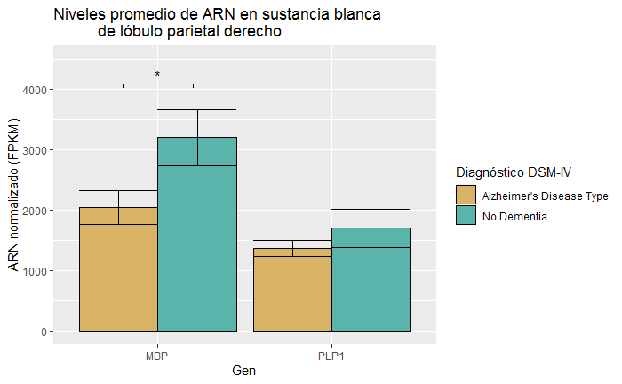

```r
Todos %>% group_by(gene_symbol, dsm_iv_clinical_diagnosis) %>%
  mutate(se = sd(value) / sqrt(length(value)), mean_value = mean(value)) %>%
      ggplot(aes(gene_symbol,mean_value,fill = dsm_iv_clinical_diagnosis)) +
      geom_bar(stat = 'identity', color="black", position = 'dodge') +
      ggsignif::geom_signif(y_position = c(4100), xmin = c(0.8), xmax = c(1.2),
                            annotation = c("*"), tip_length = 0.03) +
      scale_fill_manual(values = c("#d8b365", "#5ab4ac"))+
      geom_errorbar(aes(ymin = mean_value - se, ymax = mean_value + se),
                position = "dodge") +
      labs(x = "Gen", y = "ARN normalizado (FPKM)",
           fill = "Diagnóstico DSM-IV") +
      ggtitle("Niveles promedio de ARN en sustancia blanca
          de lóbulo parietal derecho") +
      ylim(0,4500)
```

### Gráfico de cajas y bigotes

Hacemos un gráfico de cajas y bigotes con asterisco indicando en cuál variable se encuentra la diferencia (no confundir con el punto del valor atípico).

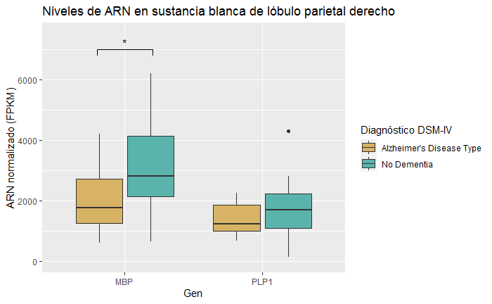

```r
Todos %>% group_by(gene_symbol, dsm_iv_clinical_diagnosis) %>%
  ggplot(aes(gene_symbol,value,fill = dsm_iv_clinical_diagnosis)) +
  geom_boxplot() +
  ggsignif::geom_signif(y_position = c(7000),
                        xmin = c(0.8), xmax = c(1.2),
                        annotation = c("*"), tip_length = 0.03)+
  scale_fill_manual(values = c("#d8b365", "#5ab4ac")) +
  labs(x = "Gen",y = "ARN normalizado (FPKM)", fill = "Diagnóstico DSM-IV") +
  ggtitle("Niveles de ARN en sustancia blanca de lóbulo parietal derecho") +
  ylim(0,7500)
```